# Analyzing Forest Fires

```r
require(tidyverse)
require(ggplot2)

forestfires <- read.csv("forestfires.csv")
head(forestfires, 50)
```

|  | X | Y | month | day | FFMC | DMC | DC | ISI | temp | RH | wind | rain | area |
| --- | --- | --- | --- | --- | --- | --- | --- | --- | --- | --- | --- | --- | --- |
| 1 | 7 | 5 | mar | fri | 86.2 | 26.2 | 94.3 | 5.1 | 8.2 | 51 | 6.7 | 0.0 | 0 |
| 2 | 7 | 4 | oct | tue | 90.6 | 35.4 | 669.1 | 6.7 | 18.0 | 33 | 0.9 | 0.0 | 0 |
| 3 | 7 | 4 | oct | sat | 90.6 | 43.7 | 686.9 | 6.7 | 14.6 | 33 | 1.3 | 0.0 | 0 |
| 4 | 8 | 6 | mar | fri | 91.7 | 33.3 | 77.5 | 9.0 | 8.3 | 97 | 4.0 | 0.2 | 0 |
| 5 | 8 | 6 | mar | sun | 89.3 | 51.3 | 102.2 | 9.6 | 11.4 | 99 | 1.8 | 0.0 | 0 |
| 6 | 8 | 6 | aug | sun | 92.3 | 85.3 | 488.0 | 14.7 | 22.2 | 29 | 5.4 | 0.0 | 0 |
| 7 | 8 | 6 | aug | mon | 92.3 | 88.9 | 495.6 | 8.5 | 24.1 | 27 | 3.1 | 0.0 | 0 |
| 8 | 8 | 6 | aug | mon | 91.5 | 145.4 | 608.2 | 10.7 | 8.0 | 86 | 2.2 | 0.0 | 0 |
| 9 | 8 | 6 | sep | tue | 91.0 | 129.5 | 692.6 | 7.0 | 13.1 | 63 | 5.4 | 0.0 | 0 |
| 10 | 7 | 5 | sep | sat | 92.5 | 88.0 | 698.6 | 7.1 | 22.8 | 40 | 4.0 | 0.0 | 0 |

[output cut: 40 more lines]

Loading tidyverse and ggplot2 packages and importing the forest fire csv file into a dataframe. We use head to look at the first several rows in order to get a sense of the structure and formatting of the data.

```r
forestfires %>% pull(month) %>% unique()
```

```
 [1] "mar" "oct" "aug" "sep" "apr" "jun" "jul" "feb" "jan"
[10] "dec" "may" "nov"
```

```r
forestfires %>% pull(day) %>% unique()
```

```
[1] "fri" "tue" "sat" "sun" "mon" "wed" "thu"
```

Taking a look at the month and day variables we can see how they are abbreviated as well as how they are ordered.

```r
forestfires <- forestfires %>%
    mutate(
      month = factor(month, levels = c("jan", "feb", "mar", "apr", "may", "jun", "jul", "aug", "sep", "oct", "nov", "dec")),
      day = factor(day, levels = c("mon", "tue", "wed", "thu", "fri", "sat", "sun"))
    )
```

We can change the order of the month and day variables as well as changing them into categorical variables.

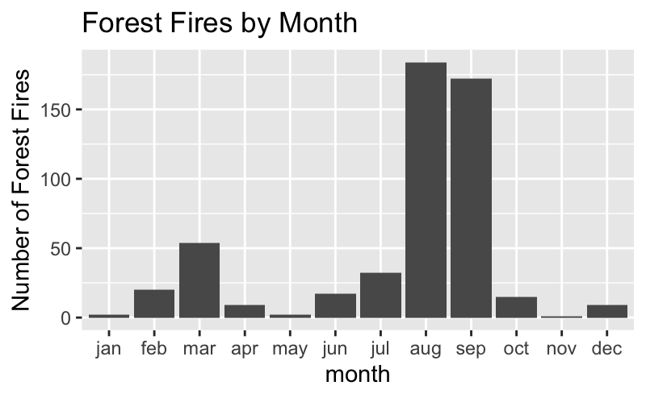

```r
numff.month <- forestfires %>%
  group_by(month) %>%
  summarize(
   n = n()
  )
numff.day <- forestfires %>%
  group_by(day) %>%
  summarize(
   n = n()
  )
numff.month %>%
      ggplot(aes(x = month, y = n)) +
      geom_col() +
      labs(
        title = "Forest Fires by Month",
        y = "Number of Forest Fires")
```

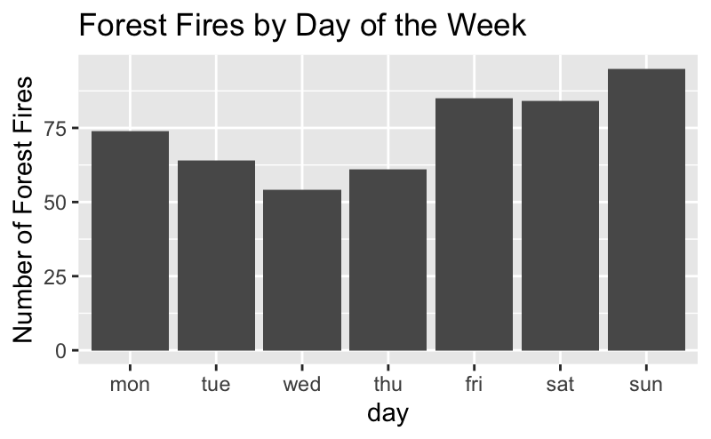

```r
numff.day %>%
      ggplot(aes(x = day, y = n)) +
      geom_col() +
      labs(
        title = "Forest Fires by Day of the Week",
        y = "Number of Forest Fires")
```

We group the data by both month and day, then summarize the dataframes by counting the number of observations for each month/day and load those summaries into a new data frame, respectively. Thanks to the categoricalization of the variables ‘month’ and ‘day’ we are able to have the designated order in our graphs.

Quick takeaways; Peak forest fire season is within the months of the August and September. Additionally, forest fires tend to occur during the weekend i.e. Friday-Sunday.

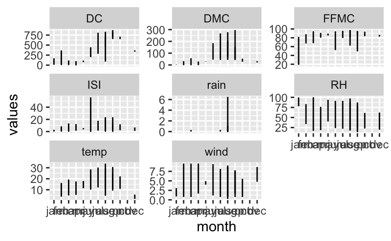

```r
forestfires_long <- forestfires %>%
  pivot_longer(
    cols = c(FFMC, DMC, DC, ISI, temp, RH, wind, rain),
    names_to = "variables",
    values_to = "values"
  )
forestfires_long %>%
  ggplot(aes(x=month, y=values)) +
  geom_line() +
  facet_wrap(vars(variables),
  scales = "free_y")
```

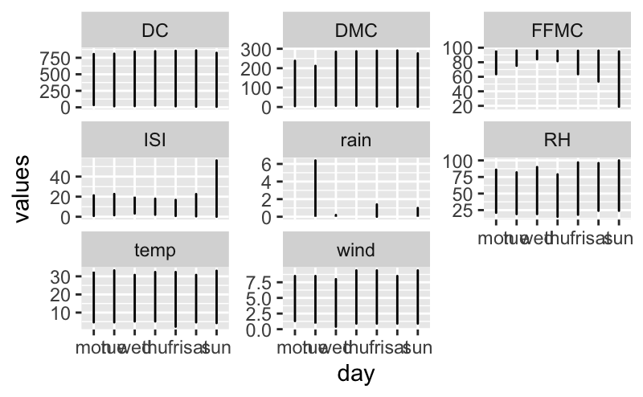

```r
forestfires_long %>%
  ggplot(aes(x=day, y=values)) +
  geom_line() +
  facet_wrap(vars(variables),
  scales = "free_y")
```

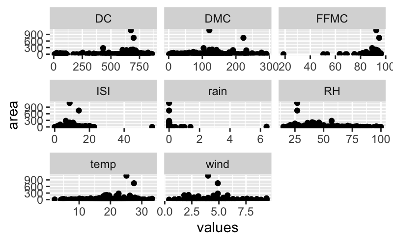

```r
forestfires_long %>%
  ggplot(aes(x=values, y=area)) +
  geom_point() +
  facet_wrap(vars(variables) ,
  scales = "free_x")
```

```r
cor_ff <- cor(forestfires[13], forestfires[5:12], method = "spearman")
head(cor_ff)
```

```
           FFMC        DMC         DC        ISI       temp
area 0.02530046 0.07191967 0.06163303 0.01249593 0.07869596
              RH       wind        rain
area -0.02422121 0.05319584 -0.06407348
```

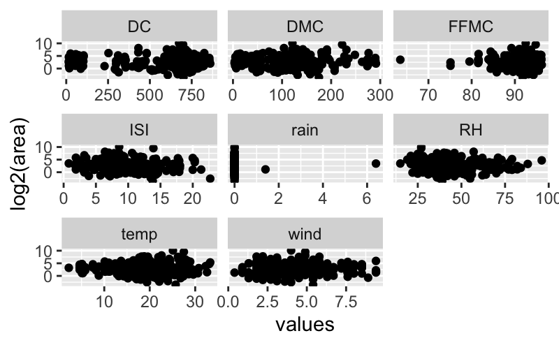

```r
forestfires_long_filter <- forestfires_long %>%
  filter(area > 0)
forestfires_long_filter %>%
  ggplot(aes(x=values, y=log2(area))) +
  geom_point() +
  facet_wrap(vars(variables) ,
  scales = "free_x")
```

```r
NA
```